# C:\Users\Mehdi\Desktop\pro 3

## Ford Go Bike 2019

## Exploratory Data Analysis

In this first part, i will conduct an exploratory data analysis on Ford Go Bike 2019 Dataset.

I Will Use Python data science and data visualization libraries to explore the dataset’s variables

and understand the data’s structure, oddities, patterns, and relationships.

# Introduction

Through this project we will use Exploratory Data Analysis to answer a lot of questions about the data’s structure, oddities, patterns, and relationships

```
is Age has an effect on trips ('duration','distance') ?

is Gender has an effect on trips ('duration','distance') ?

is there any correlation between duration and distance?

What is the effect of type user on trips ?
```

```python
## import lib
# import all packages and set plots to be embedded inline
import numpy as np
import pandas as pd
import matplotlib.pyplot as plt
import seaborn as sns
import calendar
import math
import time
from scipy import stats
%matplotlib inline
from matplotlib.pyplot import figure
```

## Data Wrangling

```python
## read the csv file
data = pd.read_csv('201902-fordgobike-tripdata.csv')
```

## The structure of the dataset

```python
data.info()
```

```
<class 'pandas.core.frame.DataFrame'>
RangeIndex: 183412 entries, 0 to 183411
Data columns (total 16 columns):
 #   Column                   Non-Null Count   Dtype
---  ------                   --------------   -----
 0   duration_sec             183412 non-null  int64
 1   start_time               183412 non-null  object
 2   end_time                 183412 non-null  object
 3   start_station_id         183215 non-null  float64
 4   start_station_name       183215 non-null  object
 5   start_station_latitude   183412 non-null  float64
 6   start_station_longitude  183412 non-null  float64
 7   end_station_id           183215 non-null  float64
 8   end_station_name         183215 non-null  object
 9   end_station_latitude     183412 non-null  float64
 10  end_station_longitude    183412 non-null  float64
 11  bike_id                  183412 non-null  int64
 12  user_type                183412 non-null  object
 13  member_birth_year        175147 non-null  float64
 14  member_gender            175147 non-null  object
 15  bike_share_for_all_trip  183412 non-null  object
dtypes: float64(7), int64(2), object(7)
memory usage: 22.4+ MB
```

```python
data.head()
```

|  | duration_sec | start_time | end_time | start_station_id | start_station_name | start_station_latitude | start_station_longitude | end_station_id | end_station_name | end_station_latitude | end_station_longitude | bike_id | user_type | member_birth_year | member_gender | bike_share_for_all_trip |
| --- | --- | --- | --- | --- | --- | --- | --- | --- | --- | --- | --- | --- | --- | --- | --- | --- |
| 0 | 52185 | 2019-02-28 17:32:10.1450 | 2019-03-01 08:01:55.9750 | 21.0 | Montgomery St BART Station (Market St at 2nd St) | 37.789625 | -122.400811 | 13.0 | Commercial St at Montgomery St | 37.794231 | -122.402923 | 4902 | Customer | 1984.0 | Male | No |
| 1 | 42521 | 2019-02-28 18:53:21.7890 | 2019-03-01 06:42:03.0560 | 23.0 | The Embarcadero at Steuart St | 37.791464 | -122.391034 | 81.0 | Berry St at 4th St | 37.775880 | -122.393170 | 2535 | Customer | NaN | NaN | No |
| 2 | 61854 | 2019-02-28 12:13:13.2180 | 2019-03-01 05:24:08.1460 | 86.0 | Market St at Dolores St | 37.769305 | -122.426826 | 3.0 | Powell St BART Station (Market St at 4th St) | 37.786375 | -122.404904 | 5905 | Customer | 1972.0 | Male | No |
| 3 | 36490 | 2019-02-28 17:54:26.0100 | 2019-03-01 04:02:36.8420 | 375.0 | Grove St at Masonic Ave | 37.774836 | -122.446546 | 70.0 | Central Ave at Fell St | 37.773311 | -122.444293 | 6638 | Subscriber | 1989.0 | Other | No |
| 4 | 1585 | 2019-02-28 23:54:18.5490 | 2019-03-01 00:20:44.0740 | 7.0 | Frank H Ogawa Plaza | 37.804562 | -122.271738 | 222.0 | 10th Ave at E 15th St | 37.792714 | -122.248780 | 4898 | Subscriber | 1974.0 | Male | Yes |

- I need to convert duration_sec to duration_min by duration_sec / 60
- I will use start_station_latitude start_station_longitude and end_station_latitude end_station_longitude

  to have Distance by using definition of Haversine
- using start_time end_time to create new columns to know if the ride is in morning or midnight
- convert the member_birth_year to member_age by (2019 - member_birth_year)
- The time variables in this dataset are all string. They need to be converted to datetime format for the analysis.

## The main interest in the dataset

the relationship between age , sex, user_type and Distance , duration

# Create Distance column

```python
# The Function for Distance measurment with Lat and long coordinates
Distance = []
def Haversine(lat1,lon1,lat2,lon2, **kwarg):

    R = 6371.0088
    lat1,lon1,lat2,lon2 = map(np.radians, [lat1,lon1,lat2,lon2])

    dlat = lat2 - lat1
    dlon = lon2 - lon1
    a = np.sin(dlat/2)**2 + np.cos(lat1) * np.cos(lat2) * np.sin(dlon/2) **2
    c = 2 * np.arctan2(a**0.5, (1-a)**0.5)
    d = R * c

    return round(d,4)
```

```python
start_station_latitude= data['start_station_latitude']

start_station_longitude = data['start_station_longitude']*(-1)

end_station_latitude = data['end_station_latitude']

end_station_longitude = data['end_station_longitude']*(-1)

Distance = Haversine(start_station_latitude,start_station_longitude,end_station_latitude,end_station_longitude)
```

```python
data['Distance_Km'] = Distance
```

```python
# Test Distance_Km
data.head()
```

|  | duration_sec | start_time | end_time | start_station_id | start_station_name | start_station_latitude | start_station_longitude | end_station_id | end_station_name | end_station_latitude | end_station_longitude | bike_id | user_type | member_birth_year | member_gender | bike_share_for_all_trip | Distance_Km |
| --- | --- | --- | --- | --- | --- | --- | --- | --- | --- | --- | --- | --- | --- | --- | --- | --- | --- |
| 0 | 52185 | 2019-02-28 17:32:10.1450 | 2019-03-01 08:01:55.9750 | 21.0 | Montgomery St BART Station (Market St at 2nd St) | 37.789625 | -122.400811 | 13.0 | Commercial St at Montgomery St | 37.794231 | -122.402923 | 4902 | Customer | 1984.0 | Male | No | 0.5447 |
| 1 | 42521 | 2019-02-28 18:53:21.7890 | 2019-03-01 06:42:03.0560 | 23.0 | The Embarcadero at Steuart St | 37.791464 | -122.391034 | 81.0 | Berry St at 4th St | 37.775880 | -122.393170 | 2535 | Customer | NaN | NaN | No | 1.7430 |
| 2 | 61854 | 2019-02-28 12:13:13.2180 | 2019-03-01 05:24:08.1460 | 86.0 | Market St at Dolores St | 37.769305 | -122.426826 | 3.0 | Powell St BART Station (Market St at 4th St) | 37.786375 | -122.404904 | 5905 | Customer | 1972.0 | Male | No | 2.7045 |
| 3 | 36490 | 2019-02-28 17:54:26.0100 | 2019-03-01 04:02:36.8420 | 375.0 | Grove St at Masonic Ave | 37.774836 | -122.446546 | 70.0 | Central Ave at Fell St | 37.773311 | -122.444293 | 6638 | Subscriber | 1989.0 | Other | No | 0.2607 |
| 4 | 1585 | 2019-02-28 23:54:18.5490 | 2019-03-01 00:20:44.0740 | 7.0 | Frank H Ogawa Plaza | 37.804562 | -122.271738 | 222.0 | 10th Ave at E 15th St | 37.792714 | -122.248780 | 4898 | Subscriber | 1974.0 | Male | Yes | 2.4093 |

```python
## drop the 4 columns start_station_latitude	start_station_longitude end_station_latitude	end_station_longitude
data  = data.drop(['start_station_latitude','start_station_longitude','end_station_latitude','end_station_longitude'],axis = 1)
```

## Creating Age column

```python
# Age member
data['age'] = 2019 - data['member_birth_year']
```

```python
data = data.drop(['member_birth_year'], axis = 1)
```

```python
# Test Age Column
data.head()
```

|  | duration_sec | start_time | end_time | start_station_id | start_station_name | end_station_id | end_station_name | bike_id | user_type | member_gender | bike_share_for_all_trip | Distance_Km | age |
| --- | --- | --- | --- | --- | --- | --- | --- | --- | --- | --- | --- | --- | --- |
| 0 | 52185 | 2019-02-28 17:32:10.1450 | 2019-03-01 08:01:55.9750 | 21.0 | Montgomery St BART Station (Market St at 2nd St) | 13.0 | Commercial St at Montgomery St | 4902 | Customer | Male | No | 0.5447 | 35.0 |
| 1 | 42521 | 2019-02-28 18:53:21.7890 | 2019-03-01 06:42:03.0560 | 23.0 | The Embarcadero at Steuart St | 81.0 | Berry St at 4th St | 2535 | Customer | NaN | No | 1.7430 | NaN |
| 2 | 61854 | 2019-02-28 12:13:13.2180 | 2019-03-01 05:24:08.1460 | 86.0 | Market St at Dolores St | 3.0 | Powell St BART Station (Market St at 4th St) | 5905 | Customer | Male | No | 2.7045 | 47.0 |
| 3 | 36490 | 2019-02-28 17:54:26.0100 | 2019-03-01 04:02:36.8420 | 375.0 | Grove St at Masonic Ave | 70.0 | Central Ave at Fell St | 6638 | Subscriber | Other | No | 0.2607 | 30.0 |
| 4 | 1585 | 2019-02-28 23:54:18.5490 | 2019-03-01 00:20:44.0740 | 7.0 | Frank H Ogawa Plaza | 222.0 | 10th Ave at E 15th St | 4898 | Subscriber | Male | Yes | 2.4093 | 45.0 |

## Creating duration_min column

```python
data['duration_min'] = round(data['duration_sec'] / 60,2)
data['duration_hour'] = round(data['duration_min'] / 60,2)
```

```python
data = data.drop(['duration_sec'] , axis = 1)
```

```python
# Test
data.head()
```

|  | start_time | end_time | start_station_id | start_station_name | end_station_id | end_station_name | bike_id | user_type | member_gender | bike_share_for_all_trip | Distance_Km | age | duration_min | duration_hour |
| --- | --- | --- | --- | --- | --- | --- | --- | --- | --- | --- | --- | --- | --- | --- |
| 0 | 2019-02-28 17:32:10.1450 | 2019-03-01 08:01:55.9750 | 21.0 | Montgomery St BART Station (Market St at 2nd St) | 13.0 | Commercial St at Montgomery St | 4902 | Customer | Male | No | 0.5447 | 35.0 | 869.75 | 14.50 |
| 1 | 2019-02-28 18:53:21.7890 | 2019-03-01 06:42:03.0560 | 23.0 | The Embarcadero at Steuart St | 81.0 | Berry St at 4th St | 2535 | Customer | NaN | No | 1.7430 | NaN | 708.68 | 11.81 |
| 2 | 2019-02-28 12:13:13.2180 | 2019-03-01 05:24:08.1460 | 86.0 | Market St at Dolores St | 3.0 | Powell St BART Station (Market St at 4th St) | 5905 | Customer | Male | No | 2.7045 | 47.0 | 1030.90 | 17.18 |
| 3 | 2019-02-28 17:54:26.0100 | 2019-03-01 04:02:36.8420 | 375.0 | Grove St at Masonic Ave | 70.0 | Central Ave at Fell St | 6638 | Subscriber | Other | No | 0.2607 | 30.0 | 608.17 | 10.14 |
| 4 | 2019-02-28 23:54:18.5490 | 2019-03-01 00:20:44.0740 | 7.0 | Frank H Ogawa Plaza | 222.0 | 10th Ave at E 15th St | 4898 | Subscriber | Male | Yes | 2.4093 | 45.0 | 26.42 | 0.44 |

## Gather informations from start_time and end_time Columns

```python
# i will Create a function to convert end ans start time to more columns as Month , periode day for more informatiom

def Date(col):
# 1. Convert time variables from string to datetime
# a. month of the year
    data[col] = pd.to_datetime(data[col])
    data[col + '_month_num'] = data[col].apply(lambda time: time.month)
    data[col + '_month_char'] = data[col + '_month_num'].apply(lambda x: calendar.month_abbr[x])
# b. morning, afternoon, night of a day
    data[col + '_hour'] = data[col].apply(lambda time: time.hour)
    data[col + '_period_day'] = 'morning'
    data[col + '_period_day'][(data[col + '_hour'] >= 12) & (data[col + '_hour'] <= 17)] = 'afternoon'
    data[col + '_period_day'][(data[col + '_hour'] >= 18) & (data[col + '_hour'] <= 23)] = 'night'

    return data
```

```python
Date('start_time')
Date('end_time')
```

|  | start_time | end_time | start_station_id | start_station_name | end_station_id | end_station_name | bike_id | user_type | member_gender | bike_share_for_all_trip | ... | duration_min | duration_hour | start_time_month_num | start_time_month_char | start_time_hour | start_time_period_day | end_time_month_num | end_time_month_char | end_time_hour | end_time_period_day |
| --- | --- | --- | --- | --- | --- | --- | --- | --- | --- | --- | --- | --- | --- | --- | --- | --- | --- | --- | --- | --- | --- |
| 0 | 2019-02-28 17:32:10.145 | 2019-03-01 08:01:55.975 | 21.0 | Montgomery St BART Station (Market St at 2nd St) | 13.0 | Commercial St at Montgomery St | 4902 | Customer | Male | No | ... | 869.75 | 14.50 | 2 | Feb | 17 | afternoon | 3 | Mar | 8 | morning |
| 1 | 2019-02-28 18:53:21.789 | 2019-03-01 06:42:03.056 | 23.0 | The Embarcadero at Steuart St | 81.0 | Berry St at 4th St | 2535 | Customer | NaN | No | ... | 708.68 | 11.81 | 2 | Feb | 18 | night | 3 | Mar | 6 | morning |
| 2 | 2019-02-28 12:13:13.218 | 2019-03-01 05:24:08.146 | 86.0 | Market St at Dolores St | 3.0 | Powell St BART Station (Market St at 4th St) | 5905 | Customer | Male | No | ... | 1030.90 | 17.18 | 2 | Feb | 12 | afternoon | 3 | Mar | 5 | morning |
| 3 | 2019-02-28 17:54:26.010 | 2019-03-01 04:02:36.842 | 375.0 | Grove St at Masonic Ave | 70.0 | Central Ave at Fell St | 6638 | Subscriber | Other | No | ... | 608.17 | 10.14 | 2 | Feb | 17 | afternoon | 3 | Mar | 4 | morning |
| 4 | 2019-02-28 23:54:18.549 | 2019-03-01 00:20:44.074 | 7.0 | Frank H Ogawa Plaza | 222.0 | 10th Ave at E 15th St | 4898 | Subscriber | Male | Yes | ... | 26.42 | 0.44 | 2 | Feb | 23 | night | 3 | Mar | 0 | morning |
| ... | ... | ... | ... | ... | ... | ... | ... | ... | ... | ... | ... | ... | ... | ... | ... | ... | ... | ... | ... | ... | ... |
| 183407 | 2019-02-01 00:04:49.724 | 2019-02-01 00:12:50.034 | 27.0 | Beale St at Harrison St | 324.0 | Union Square (Powell St at Post St) | 4832 | Subscriber | Male | No | ... | 8.00 | 0.13 | 2 | Feb | 0 | morning | 2 | Feb | 0 | morning |
| 183408 | 2019-02-01 00:05:34.744 | 2019-02-01 00:10:48.502 | 21.0 | Montgomery St BART Station (Market St at 2nd St) | 66.0 | 3rd St at Townsend St | 4960 | Subscriber | Male | No | ... | 5.22 | 0.09 | 2 | Feb | 0 | morning | 2 | Feb | 0 | morning |
| 183409 | 2019-02-01 00:06:05.549 | 2019-02-01 00:08:27.220 | 278.0 | The Alameda at Bush St | 277.0 | Morrison Ave at Julian St | 3824 | Subscriber | Male | Yes | ... | 2.35 | 0.04 | 2 | Feb | 0 | morning | 2 | Feb | 0 | morning |
| 183410 | 2019-02-01 00:05:34.360 | 2019-02-01 00:07:54.287 | 220.0 | San Pablo Ave at MLK Jr Way | 216.0 | San Pablo Ave at 27th St | 5095 | Subscriber | Male | No | ... | 2.32 | 0.04 | 2 | Feb | 0 | morning | 2 | Feb | 0 | morning |
| 183411 | 2019-02-01 00:00:20.636 | 2019-02-01 00:04:52.058 | 24.0 | Spear St at Folsom St | 37.0 | 2nd St at Folsom St | 1057 | Subscriber | Male | No | ... | 4.52 | 0.08 | 2 | Feb | 0 | morning | 2 | Feb | 0 | morning |

183412 rows × 22 columns

```python
# c. Day of the week
columns = ['start_time', 'end_time']
for col in columns :

    data[col + '_weekday_num'] = data[col].apply(lambda time: time.dayofweek)
    dmap = {0:'Mon',1:'Tue',2:'Wed',3:'Thu',4:'Fri',5:'Sat',6:'Sun'}
    data[col + '_weekday_char'] = data[col + '_weekday_num'].map(dmap)
```

```python
# Test data
data.head()
```

|  | start_time | end_time | start_station_id | start_station_name | end_station_id | end_station_name | bike_id | user_type | member_gender | bike_share_for_all_trip | ... | start_time_hour | start_time_period_day | end_time_month_num | end_time_month_char | end_time_hour | end_time_period_day | start_time_weekday_num | start_time_weekday_char | end_time_weekday_num | end_time_weekday_char |
| --- | --- | --- | --- | --- | --- | --- | --- | --- | --- | --- | --- | --- | --- | --- | --- | --- | --- | --- | --- | --- | --- |
| 0 | 2019-02-28 17:32:10.145 | 2019-03-01 08:01:55.975 | 21.0 | Montgomery St BART Station (Market St at 2nd St) | 13.0 | Commercial St at Montgomery St | 4902 | Customer | Male | No | ... | 17 | afternoon | 3 | Mar | 8 | morning | 3 | Thu | 4 | Fri |
| 1 | 2019-02-28 18:53:21.789 | 2019-03-01 06:42:03.056 | 23.0 | The Embarcadero at Steuart St | 81.0 | Berry St at 4th St | 2535 | Customer | NaN | No | ... | 18 | night | 3 | Mar | 6 | morning | 3 | Thu | 4 | Fri |
| 2 | 2019-02-28 12:13:13.218 | 2019-03-01 05:24:08.146 | 86.0 | Market St at Dolores St | 3.0 | Powell St BART Station (Market St at 4th St) | 5905 | Customer | Male | No | ... | 12 | afternoon | 3 | Mar | 5 | morning | 3 | Thu | 4 | Fri |
| 3 | 2019-02-28 17:54:26.010 | 2019-03-01 04:02:36.842 | 375.0 | Grove St at Masonic Ave | 70.0 | Central Ave at Fell St | 6638 | Subscriber | Other | No | ... | 17 | afternoon | 3 | Mar | 4 | morning | 3 | Thu | 4 | Fri |
| 4 | 2019-02-28 23:54:18.549 | 2019-03-01 00:20:44.074 | 7.0 | Frank H Ogawa Plaza | 222.0 | 10th Ave at E 15th St | 4898 | Subscriber | Male | Yes | ... | 23 | night | 3 | Mar | 0 | morning | 3 | Thu | 4 | Fri |

5 rows × 26 columns

## Drop useless Columns

```python
data = data.drop(['start_time_month_num', 'end_time_month_num','start_time_month_num','end_time_month_num','start_time','end_time','start_station_id','end_station_id','bike_id','start_time_weekday_num','end_time_weekday_num'],axis = 1)
```

```python
#test data
data.head()
```

|  | start_station_name | end_station_name | user_type | member_gender | bike_share_for_all_trip | Distance_Km | age | duration_min | duration_hour | start_time_month_char | start_time_hour | start_time_period_day | end_time_month_char | end_time_hour | end_time_period_day | start_time_weekday_char | end_time_weekday_char |
| --- | --- | --- | --- | --- | --- | --- | --- | --- | --- | --- | --- | --- | --- | --- | --- | --- | --- |
| 0 | Montgomery St BART Station (Market St at 2nd St) | Commercial St at Montgomery St | Customer | Male | No | 0.5447 | 35.0 | 869.75 | 14.50 | Feb | 17 | afternoon | Mar | 8 | morning | Thu | Fri |
| 1 | The Embarcadero at Steuart St | Berry St at 4th St | Customer | NaN | No | 1.7430 | NaN | 708.68 | 11.81 | Feb | 18 | night | Mar | 6 | morning | Thu | Fri |
| 2 | Market St at Dolores St | Powell St BART Station (Market St at 4th St) | Customer | Male | No | 2.7045 | 47.0 | 1030.90 | 17.18 | Feb | 12 | afternoon | Mar | 5 | morning | Thu | Fri |
| 3 | Grove St at Masonic Ave | Central Ave at Fell St | Subscriber | Other | No | 0.2607 | 30.0 | 608.17 | 10.14 | Feb | 17 | afternoon | Mar | 4 | morning | Thu | Fri |
| 4 | Frank H Ogawa Plaza | 10th Ave at E 15th St | Subscriber | Male | Yes | 2.4093 | 45.0 | 26.42 | 0.44 | Feb | 23 | night | Mar | 0 | morning | Thu | Fri |

## remove null values

```python
## see how much nulls values
data.isnull().sum()
```

```
start_station_name          197
end_station_name            197
user_type                     0
member_gender              8265
bike_share_for_all_trip       0
Distance_Km                   0
age                        8265
duration_min                  0
duration_hour                 0
start_time_month_char         0
start_time_hour               0
start_time_period_day         0
end_time_month_char           0
end_time_hour                 0
end_time_period_day           0
start_time_weekday_char       0
end_time_weekday_char         0
dtype: int64
```

```python
## drop all null values
data = data.dropna()
```

```python
## test data
data.info()
```

```
<class 'pandas.core.frame.DataFrame'>
Int64Index: 174952 entries, 0 to 183411
Data columns (total 17 columns):
 #   Column                   Non-Null Count   Dtype
---  ------                   --------------   -----
 0   start_station_name       174952 non-null  object
 1   end_station_name         174952 non-null  object
 2   user_type                174952 non-null  object
 3   member_gender            174952 non-null  object
 4   bike_share_for_all_trip  174952 non-null  object
 5   Distance_Km              174952 non-null  float64
 6   age                      174952 non-null  float64
 7   duration_min             174952 non-null  float64
 8   duration_hour            174952 non-null  float64
 9   start_time_month_char    174952 non-null  object
 10  start_time_hour          174952 non-null  int64
 11  start_time_period_day    174952 non-null  object
 12  end_time_month_char      174952 non-null  object
 13  end_time_hour            174952 non-null  int64
 14  end_time_period_day      174952 non-null  object
 15  start_time_weekday_char  174952 non-null  object
 16  end_time_weekday_char    174952 non-null  object
dtypes: float64(4), int64(2), object(11)
memory usage: 24.0+ MB
```

```python
data.head()
```

|  | start_station_name | end_station_name | user_type | member_gender | bike_share_for_all_trip | Distance_Km | age | duration_min | duration_hour | start_time_month_char | start_time_hour | start_time_period_day | end_time_month_char | end_time_hour | end_time_period_day | start_time_weekday_char | end_time_weekday_char |
| --- | --- | --- | --- | --- | --- | --- | --- | --- | --- | --- | --- | --- | --- | --- | --- | --- | --- |
| 0 | Montgomery St BART Station (Market St at 2nd St) | Commercial St at Montgomery St | Customer | Male | No | 0.5447 | 35.0 | 869.75 | 14.50 | Feb | 17 | afternoon | Mar | 8 | morning | Thu | Fri |
| 2 | Market St at Dolores St | Powell St BART Station (Market St at 4th St) | Customer | Male | No | 2.7045 | 47.0 | 1030.90 | 17.18 | Feb | 12 | afternoon | Mar | 5 | morning | Thu | Fri |
| 3 | Grove St at Masonic Ave | Central Ave at Fell St | Subscriber | Other | No | 0.2607 | 30.0 | 608.17 | 10.14 | Feb | 17 | afternoon | Mar | 4 | morning | Thu | Fri |
| 4 | Frank H Ogawa Plaza | 10th Ave at E 15th St | Subscriber | Male | Yes | 2.4093 | 45.0 | 26.42 | 0.44 | Feb | 23 | night | Mar | 0 | morning | Thu | Fri |
| 5 | 4th St at Mission Bay Blvd S | Broadway at Kearny | Subscriber | Male | No | 3.3322 | 60.0 | 29.88 | 0.50 | Feb | 23 | night | Mar | 0 | morning | Thu | Fri |

## II. Univariate Exploration

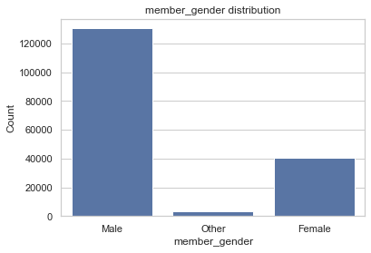

```python
# 1. distribution of member_gender
base_color = sns.color_palette()[0]
sns.countplot(data=data, x='member_gender', color=base_color)
plt.xlabel('member_gender')
plt.ylabel('Count')
plt.title('member_gender distribution');
```

as we see there is a lot of Males in this data and we will remove all 'Other' gender type cause there is no much data to study this gender

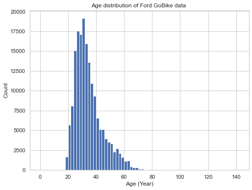

```python
# .distribution of  Age: based on the distribution, we can tell it's right skewed and has some outliers between 100 and 120.
## and a lot of member is between 20 y and 40 y
plt.figure(figsize=(8,6))
bins = np.arange(0, data['age'].max()+2, 2)
plt.hist(data=data, x='age', bins=bins)
plt.xlabel('Age (Year)')
plt.ylabel('Count')
plt.title('Age distribution of Ford GoBike data ');
```

There is some outliers we will remove age between 100y and 140y

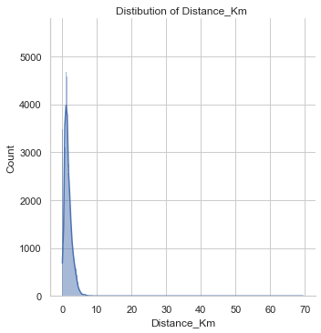

```python
## .distribution of Distance : based on the distribution, we can tell it's right skewed
sns.displot(data, x = 'Distance_Km', kde=True)
plt.title('Distibution of Distance_Km ');
```

```python
data['Distance_Km'].skew()
```

```
2.635033982165129
```

As we see here there is some values of Distance that equal to 0 we need to remove them

the skew of Ditance column is so high we need to remove outlier

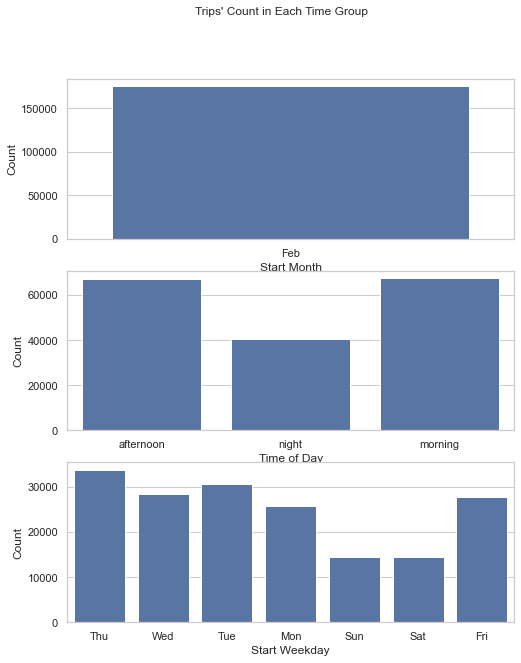

```python
# I will look into the start time factors in dataset

fig, ax = plt.subplots(nrows=3, figsize = [8,10])
default_color = sns.color_palette()[0]
sns.countplot(data = data, x = 'start_time_month_char', color = default_color, ax = ax[0])
sns.countplot(data = data, x = 'start_time_period_day', color = default_color, ax = ax[1])
sns.countplot(data = data, x = 'start_time_weekday_char', color = default_color, ax = ax[2])
ax[0].set_xlabel('Start Month')
ax[0].set_ylabel('Count')
ax[1].set_xlabel('Time of Day')
ax[1].set_ylabel('Count')
ax[2].set_xlabel('Start Weekday')
ax[2].set_ylabel('Count')
fig.suptitle('Trips\' Count in Each Time Group ');
```

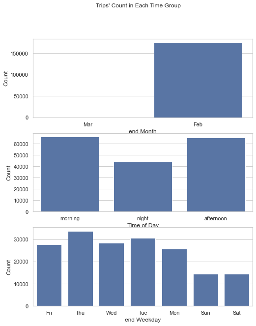

```python
# I will look into the end time factors in Datset

fig, ax = plt.subplots(nrows=3, figsize = [8,10])
default_color = sns.color_palette()[0]
sns.countplot(data = data, x = 'end_time_month_char', color = default_color, ax = ax[0])
sns.countplot(data = data, x = 'end_time_period_day', color = default_color, ax = ax[1])
sns.countplot(data = data, x = 'end_time_weekday_char', color = default_color, ax = ax[2])
ax[0].set_xlabel('end Month')
ax[0].set_ylabel('Count')
ax[1].set_xlabel('Time of Day')
ax[1].set_ylabel('Count')
ax[2].set_xlabel('end Weekday')
ax[2].set_ylabel('Count')
fig.suptitle('Trips\' Count in Each Time Group ');
```

-During the day, there are more trips in the morning and afternoon than the night.

It probably because of rush hours. Also, the number of trips in the afternoon is less than the morning. I assumed when riders

come back home, they might not be back in the afternoon.Probably, they come back during the night so some trips fall into nighttime.

-It makes sense that there are more trips during the weekdays and less trips during the weekends because of working schedule.

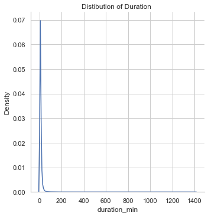

```python
 # The last factor we need to see is Duration

sns.displot(data, x= 'duration_min', kind="kde")
plt.title('Distibution of Duration ');
```

```python
data['duration_min'].skew()
```

```
28.47684354562861
```

the skew in duration is also high we will remove outliers

we will remove duration when it's equal to Zero

## Cleaning Data for Bivariate Exploration

```python
# remove if duration_min = 0 or member_gender = Other or Distance_Km = 0

data = data.loc[(data['duration_min'] != 0) & (data['Distance_Km'] != 0)]
```

```python
data = data.loc[(data['member_gender'] != 'Other')]
```

```python
# test data
data.head(10)
```

|  | start_station_name | end_station_name | user_type | member_gender | bike_share_for_all_trip | Distance_Km | age | duration_min | duration_hour | start_time_month_char | start_time_hour | start_time_period_day | end_time_month_char | end_time_hour | end_time_period_day | start_time_weekday_char | end_time_weekday_char |
| --- | --- | --- | --- | --- | --- | --- | --- | --- | --- | --- | --- | --- | --- | --- | --- | --- | --- |
| 0 | Montgomery St BART Station (Market St at 2nd St) | Commercial St at Montgomery St | Customer | Male | No | 0.5447 | 35.0 | 869.75 | 14.50 | Feb | 17 | afternoon | Mar | 8 | morning | Thu | Fri |
| 2 | Market St at Dolores St | Powell St BART Station (Market St at 4th St) | Customer | Male | No | 2.7045 | 47.0 | 1030.90 | 17.18 | Feb | 12 | afternoon | Mar | 5 | morning | Thu | Fri |
| 4 | Frank H Ogawa Plaza | 10th Ave at E 15th St | Subscriber | Male | Yes | 2.4093 | 45.0 | 26.42 | 0.44 | Feb | 23 | night | Mar | 0 | morning | Thu | Fri |
| 5 | 4th St at Mission Bay Blvd S | Broadway at Kearny | Subscriber | Male | No | 3.3322 | 60.0 | 29.88 | 0.50 | Feb | 23 | night | Mar | 0 | morning | Thu | Fri |
| 6 | Palm St at Willow St | San Jose Diridon Station | Subscriber | Female | No | 2.0286 | 36.0 | 19.12 | 0.32 | Feb | 23 | night | Mar | 0 | morning | Thu | Fri |
| 7 | Washington St at Kearny St | Valencia St at 21st St | Subscriber | Male | No | 4.5326 | 30.0 | 26.92 | 0.45 | Feb | 23 | night | Mar | 0 | morning | Thu | Fri |
| 9 | Post St at Kearny St | Mission Playground | Subscriber | Male | No | 3.6641 | 27.0 | 17.48 | 0.29 | Feb | 23 | night | Mar | 0 | morning | Thu | Fri |
| 10 | Jones St at Post St | San Francisco Public Library (Grove St at Hyde... | Subscriber | Female | Yes | 0.9798 | 23.0 | 7.63 | 0.13 | Feb | 23 | night | Mar | 0 | morning | Thu | Fri |
| 11 | Civic Center/UN Plaza BART Station (Market St ... | Bryant St at 2nd St | Subscriber | Male | No | 1.6134 | 26.0 | 8.43 | 0.14 | Feb | 23 | night | Mar | 0 | morning | Thu | Fri |
| 12 | Valencia St at 21st St | Broadway at Kearny | Customer | Male | No | 4.7802 | 29.0 | 19.60 | 0.33 | Feb | 23 | night | Mar | 0 | morning | Thu | Fri |

```python
# here we gonna remove outliers from distance , duration and age
cols = ['duration_min', 'Distance_Km','age'] # one or more
for col in cols :

    Q1 = data[col].quantile(0.25)
    Q3 = data[col].quantile(0.75)
    IQR = Q3 - Q1

    data = data[~((data[col] < (Q1 - 1.5 * IQR)) |(data[col] > (Q3 + 1.5 * IQR)))]
```

```python
# test data
data.head()
```

|  | start_station_name | end_station_name | user_type | member_gender | bike_share_for_all_trip | Distance_Km | age | duration_min | duration_hour | start_time_month_char | start_time_hour | start_time_period_day | end_time_month_char | end_time_hour | end_time_period_day | start_time_weekday_char | end_time_weekday_char |
| --- | --- | --- | --- | --- | --- | --- | --- | --- | --- | --- | --- | --- | --- | --- | --- | --- | --- |
| 6 | Palm St at Willow St | San Jose Diridon Station | Subscriber | Female | No | 2.0286 | 36.0 | 19.12 | 0.32 | Feb | 23 | night | Mar | 0 | morning | Thu | Fri |
| 9 | Post St at Kearny St | Mission Playground | Subscriber | Male | No | 3.6641 | 27.0 | 17.48 | 0.29 | Feb | 23 | night | Mar | 0 | morning | Thu | Fri |
| 10 | Jones St at Post St | San Francisco Public Library (Grove St at Hyde... | Subscriber | Female | Yes | 0.9798 | 23.0 | 7.63 | 0.13 | Feb | 23 | night | Mar | 0 | morning | Thu | Fri |
| 11 | Civic Center/UN Plaza BART Station (Market St ... | Bryant St at 2nd St | Subscriber | Male | No | 1.6134 | 26.0 | 8.43 | 0.14 | Feb | 23 | night | Mar | 0 | morning | Thu | Fri |
| 14 | Bancroft Way at College Ave | Channing Way at Shattuck Ave | Subscriber | Male | No | 1.2150 | 31.0 | 6.58 | 0.11 | Feb | 23 | night | Mar | 0 | morning | Thu | Fri |

```python
# Creating the speed and duration_hour columns for better analysing process

data['duration_hour'] = round(data['duration_min'] / 60,2)
data['Speed'] = data['Distance_Km'] / data['duration_hour']
```

```python
# test data['Speed']
data['Speed']
```

```
6          6.339375
9         12.634828
10         7.536923
11        11.524286
14        11.045455
            ...
183407    11.267692
183408    15.585556
183409     9.477500
183410    18.682500
183411     8.880000
Name: Speed, Length: 150584, dtype: float64
```

Our data now it's so clean , no it's the time finding the relationships between columns

## III. Bivariate Exploration

```python
data.info()
```

```
<class 'pandas.core.frame.DataFrame'>
Int64Index: 150584 entries, 6 to 183411
Data columns (total 18 columns):
 #   Column                   Non-Null Count   Dtype
---  ------                   --------------   -----
 0   start_station_name       150584 non-null  object
 1   end_station_name         150584 non-null  object
 2   user_type                150584 non-null  object
 3   member_gender            150584 non-null  object
 4   bike_share_for_all_trip  150584 non-null  object
 5   Distance_Km              150584 non-null  float64
 6   age                      150584 non-null  float64
 7   duration_min             150584 non-null  float64
 8   duration_hour            150584 non-null  float64
 9   start_time_month_char    150584 non-null  object
 10  start_time_hour          150584 non-null  int64
 11  start_time_period_day    150584 non-null  object
 12  end_time_month_char      150584 non-null  object
 13  end_time_hour            150584 non-null  int64
 14  end_time_period_day      150584 non-null  object
 15  start_time_weekday_char  150584 non-null  object
 16  end_time_weekday_char    150584 non-null  object
 17  Speed                    150584 non-null  float64
dtypes: float64(5), int64(2), object(11)
memory usage: 21.8+ MB
```

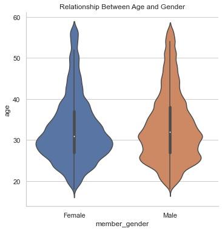

```python
# let's see the Age of women and male in this data
sns.catplot(x="member_gender", y="age",
            kind="violin", split=True, data=data)
plt.title('Relationship Between Age and Gender');
```

the age in both female and male genders has the same distrubition we have so much people between 25 and 40 years old

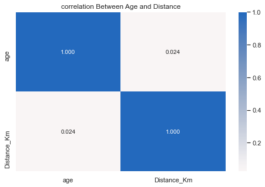

```python
# correlation between age and Distance
AD = data[['age','Distance_Km']]
plt.figure(figsize = [8, 5])
sns.heatmap(AD.corr(), annot = True, fmt = '.3f',
           cmap = 'vlag_r', center = 0)
plt.title('correlation Between Age and Distance');
```

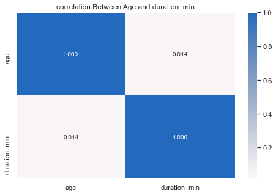

```python
# correlation between age and duration_min
AD = data[['age','duration_min']]
plt.figure(figsize = [8, 5])
sns.heatmap(AD.corr(), annot = True, fmt = '.3f',
           cmap = 'vlag_r', center = 0)
plt.title('correlation Between Age and duration_min');
```

The age has no correlation with distance and duration, that is normal cause everyone has his own distance and duration

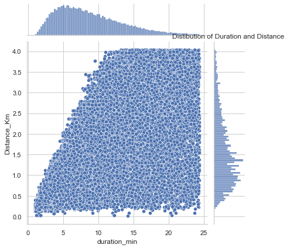

```python
# Distribution between duration and Distance
# we use
AD = data[['duration_min','Distance_Km']]

sns.jointplot(data=AD, x="duration_min", y="Distance_Km")
plt.title('Distibution of Duration and Distance ');
```

As we see there is a strong correlation beteen duration and distance

```python
#measurement of correlation between distance and duration

AD[['Distance_Km','duration_min']].corr()
```

|  | Distance_Km | duration_min |
| --- | --- | --- |
| Distance_Km | 1.000000 | 0.781377 |
| duration_min | 0.781377 | 1.000000 |

measurement of correlation between distance and duration is hight and is good for prediction and analysing

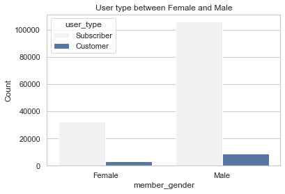

```python
# User type between Female and Male
base_color = sns.color_palette()[0]
sns.countplot(data=data, x='member_gender', hue = 'user_type', color=base_color)
plt.xlabel('member_gender')
plt.ylabel('Count')
plt.title('User type between Female and Male');
```

we have more data about subscriber people is prove that subscriber do so much riding than customer

We will go now for Multivariate for further understanding of data